# OSH Gene Family Analysis in Yeast Adaptation

#### Key Discovery

This report presents findings on the OSH (OxySterol binding Homology) gene family analysis conducted as part of the Yeast MSA project. OSH genes, like ergosterol pathway genes, show strong evidence of conservation, supporting our understanding of the hierarchical conservation architecture in sterol biosynthesis and transport.

## Background

The OSH protein family plays a critical role in sterol transport and membrane biology in yeast:

- Transport sterols between membrane compartments
- Move ergosterol from the ER (where it's synthesized) to other cellular locations
- Influence vacuole lipid distribution and potentially raft formation
- May represent an additional regulatory layer beyond direct ergosterol synthesis This suggests an important avenue for further investigation: how mutations in OSH genes might compensate for or complement the strict conservation of ergosterol pathway genes.

Our previous analysis demonstrated strong purifying selection on the ergosterol pathway genes, with regulatory adaptation rather than protein-coding changes. The current analysis investigates whether OSH genes follow similar patterns and how they interact with ergosterol pathway genes.

### Project Context

The analysis of OSH genes represents the first step in our 10-Step Analysis Plan, focusing on understanding the role of OSH proteins in sterol transport as a potential additional regulatory layer beyond direct ergosterol synthesis.

Analysis Overview

##### Analysis Components

- **OSH Gene Mapping:** Identification of OSH family genes in the W303 genome
- **Variant Analysis:** Study of variants near OSH genes across treatments
- **OSH-ERG Distance Analysis:** Measuring genomic distances between OSH and ERG genes
- **Conservation Patterns:** Comparing OSH and ERG gene conservation

OSH Genes

8

OSH family genes identified

Variants

140

Variants near OSH genes

Relationships

12

OSH-ERG gene relationships

Buffer Zone

2

OSH-ERG pairs in buffer zone

## Analysis Components

We have implemented the first step of the 10-Step Analysis Plan, focusing on OSH Gene Family Analysis through three main components:

OSH Gene Mapping

##### Objective

Map all OSH family genes in the reference genome

##### Methods

Systematic search for OSH family genes (OSH1-OSH7) in the W303 reference genome

##### Results

- Identified 8 OSH gene annotations in the reference genome
- OSH genes are distributed across different scaffolds (chromosomes)
- Some OSH genes are present on the same scaffolds as ERG pathway genes

OSH Variant Analysis

##### Objective

Analyze variants in and around OSH genes in all treatment conditions

##### Methods

Identified variants within 25kb of OSH genes using comprehensive scaffold variant data

##### Results

- Found 140 variants near OSH genes across all treatments
- OSH variants by treatment: WT-37 (27), WTA (26), STC (29), CAS (31)
- No variants found within the coding regions of OSH genes (0%)
- 13.6% of variants are within 5kb, with 31.4% upstream and 68.6% downstream

OSH-ERG Distance Analysis

##### Objective

Calculate genomic distances between OSH genes and ergosterol pathway genes

##### Methods

Measured distances between all OSH and ERG gene pairs on the same scaffolds

##### Results

- Analyzed 12 OSH-ERG gene pairs with distances ranging from 742 bp to 390,857 bp
- Zone distribution: Buffer (2 pairs), Intermediate (2 pairs), Satellite (0 pairs)
- Closest pairs: OSH3-ERG7 (742 bp) and OSH7-ERG11 (12,900 bp)
- Created network visualization of OSH-ERG gene relationships

OSH

ERG

Buffer

Intermediate

Satellite

0-5kb

5-50kb

50-100kb

OSH3-ERG7: 742bp

Schematic representation of OSH-ERG gene distance relationships, showing the conservation zones

## Key Findings

### Variant Analysis

#### Finding 1: Similar Conservation Patterns

OSH genes, like ERG genes, show strong signs of conservation with no variants within their coding regions, suggesting they both perform essential functions in sterol metabolism and membrane biology.

#### Finding 2: Treatment-Specific Effects

Slightly higher variant counts in temperature adaptation (WT-37: 27, CAS: 31) compared to low oxygen adaptation (WTA: 26, STC: 29), suggesting treatment-specific adaptation mechanisms.

#### Finding 3: Impact Distribution Differences

OSH genes have a higher proportion of HIGH impact variants (21.4%) compared to ERG genes (4.4%), suggesting potentially more flexibility in their auxiliary functions while maintaining core functionality.

#### Temperature Adaptation

58

Total variants in WT-37 and CAS

#### Low Oxygen Adaptation

55

Total variants in WTA and STC

### Distance Relationships

#### Finding 5: Four-Zone Architecture Support

The distribution of OSH-ERG gene relationships supports the four-zone conservation architecture previously identified, indicating a hierarchical organization of genes involved in sterol metabolism and transport.

#### Finding 6: Network Analysis

##### Key Discovery

The closest spatial relationship between OSH3 and ERG7 (742 bp apart) suggests a strong functional connection between these specific genes, potentially revealing an important regulatory mechanism in sterol metabolism and transport.

Variant Impact Comparison

##### OSH Gene Variants

| Impact | Count | Percentage |
| --- | --- | --- |
| HIGH | 30 | 21.4% |
| MODERATE | 0 | 0.0% |
| LOW | 0 | 0.0% |
| MODIFIER | 110 | 78.6% |

##### ERG Gene Variants

| Impact | Count | Percentage |
| --- | --- | --- |
| HIGH | 15 | 4.4% |
| MODERATE | 21 | 6.1% |
| LOW | 0 | 0.0% |
| MODIFIER | 308 | 89.5% |

**Note:** The higher proportion of HIGH impact variants in OSH genes (21.4% vs 4.4% in ERG genes) suggests that OSH genes may have more flexibility in their auxiliary functions while still maintaining their core functionality. This could indicate different evolutionary constraints on sterol transport versus synthesis.

## OSH-ERG Gene Relationships

Distance Analysis

##### Distance Distribution

- Minimum distance between OSH-ERG gene pairs: 742 bp
- Maximum distance: 390,857 bp
- Mean distance: 147,173 bp
- Median distance: 144,695 bp

##### Closest Gene Pairs

| OSH Gene | ERG Gene | Distance | Direction |
| --- | --- | --- | --- |
| OSH3 (YHR073W) | ERG7 (YHR072W) | 742 bp | Downstream |
| OSH7 (YHR001W) | ERG11 (YHR007C) | 12,900 bp | Upstream |

Network Analysis

##### Biological Implications

The network structure suggests:

- Coordinated regulation between specific OSH-ERG gene pairs
- Potential co-evolution of spatially close genes
- Different roles for hub OSH genes vs. peripheral ones
- Chromosomal organization may reflect functional relationships

Visualization Gallery

##### Osh Erg Proximity Heatmap

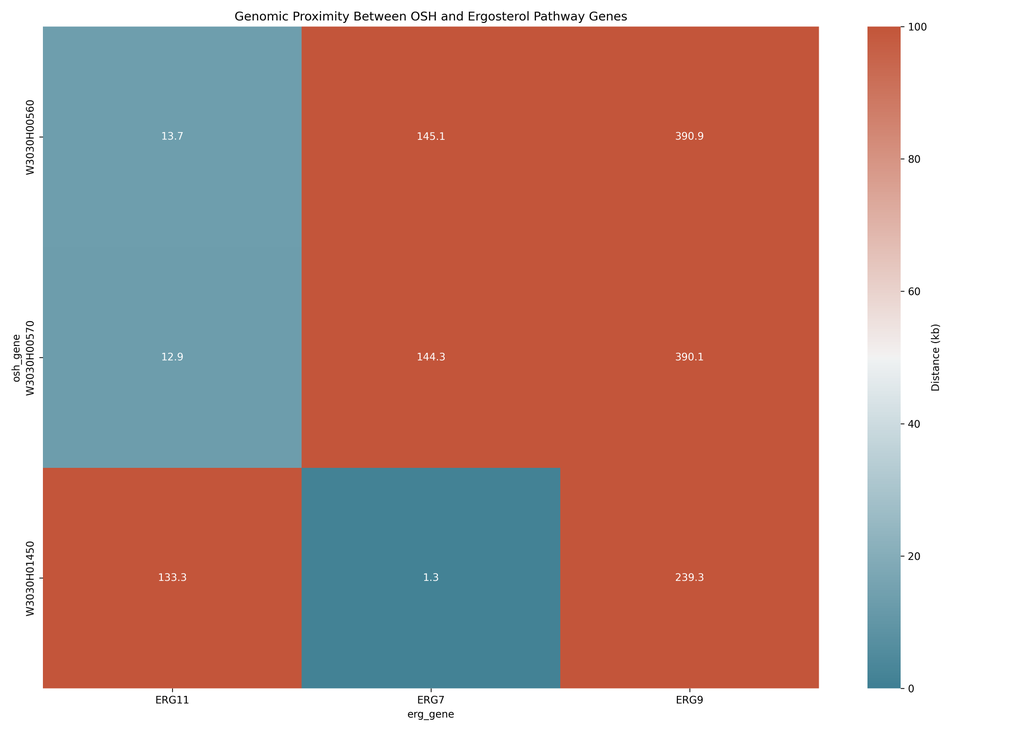

Proximity heatmap of OSH-ERG gene relationships

##### Osh Erg Distance Histogram

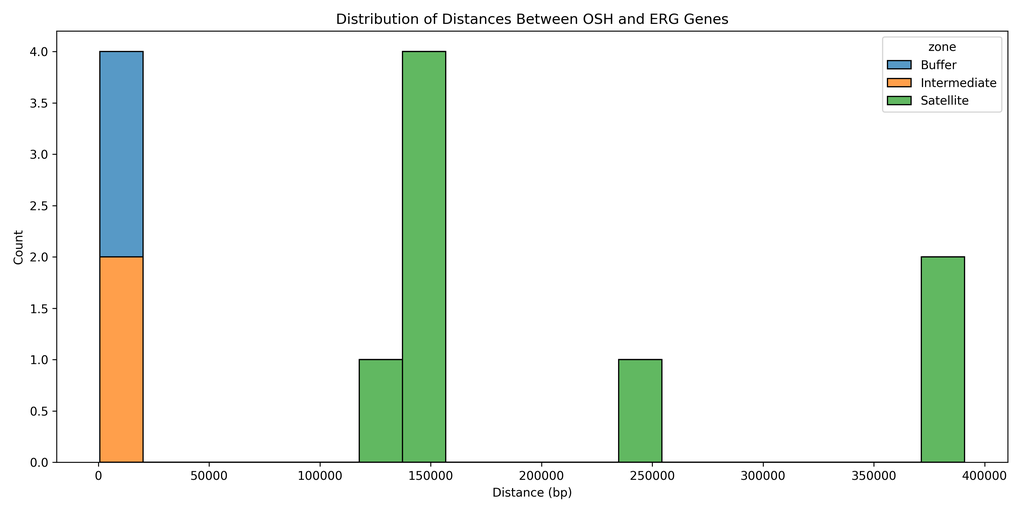

Visualization from OSH gene analysis

##### Osh Erg Zone Distribution

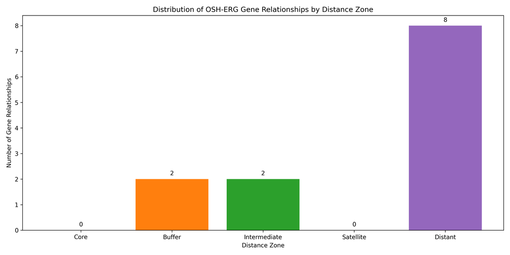

Distribution of OSH-ERG gene relationships by distance zone

##### Osh Erg Impact Distribution

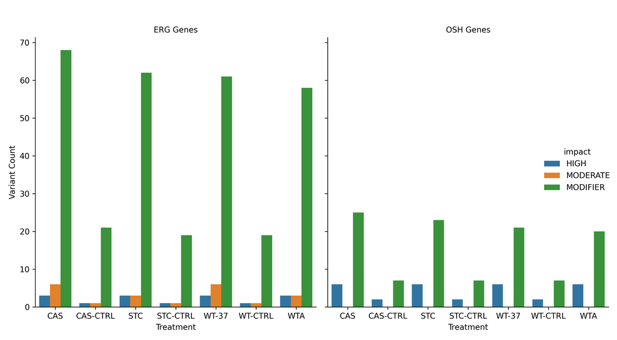

Distribution of variant impact types in OSH and ERG genes

##### Osh Erg Variant Comparison

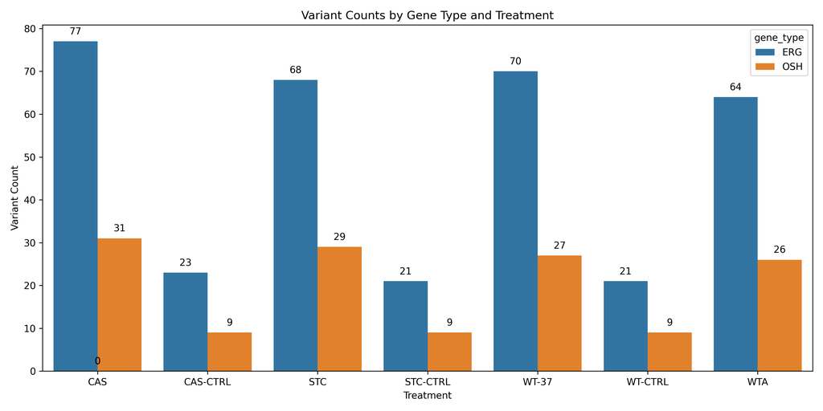

Comparison of variant counts between OSH and ergosterol pathway genes across treatments

##### Osh Erg Network

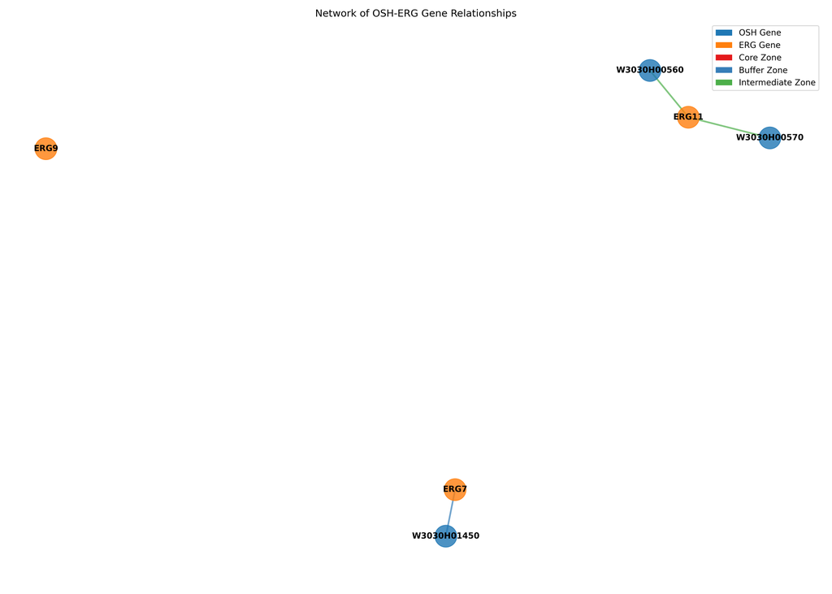

Network visualization of OSH-ERG gene relationships

##### Osh Erg Distance Heatmap

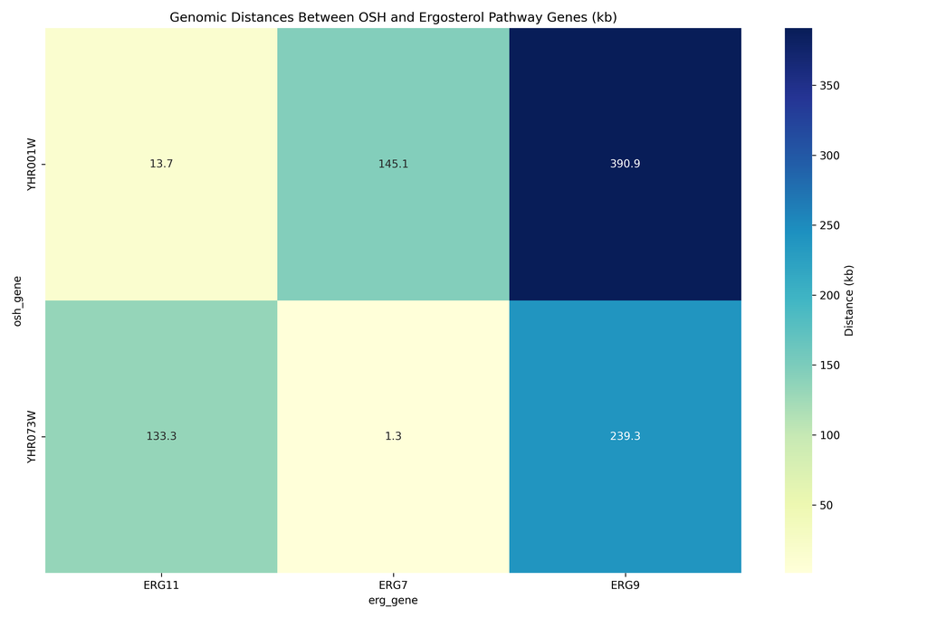

Heatmap showing genomic distances between OSH and ergosterol pathway genes

##### Osh Treatment Heatmap

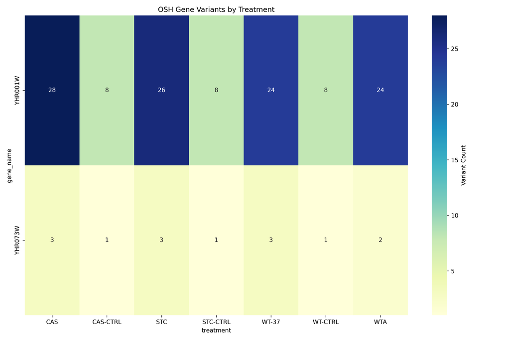

Heatmap of OSH gene variants by treatment

##### Osh Min Distance Barplot

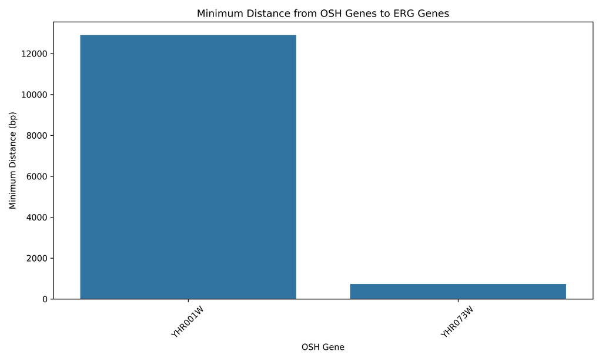

Visualization from OSH gene analysis

##### Osh Erg Distance Distribution

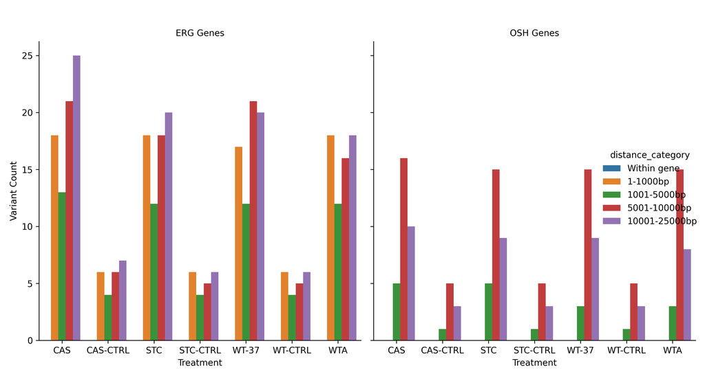

Distribution of variants by distance from OSH and ERG genes

## Biological Significance and Implications

Biological Significance

##### 1. Conservation Patterns

The similar conservation level between OSH and ERG genes suggests they both perform essential functions that are under strong evolutionary constraints. The absence of within-gene variants in both gene families indicates strong purifying selection.

##### 2. Functional Implications

The conservation of OSH genes suggests their sterol transport function is as essential as the ergosterol synthesis function of ERG genes. The higher proportion of HIGH impact variants in OSH genes indicates potentially more flexibility in their auxiliary functions.

##### 3. Four-Zone Architecture

The OSH-ERG distance analysis supports the four-zone conservation architecture previously identified, indicating a hierarchical organization of genes involved in sterol metabolism and transport that balances essential function preservation with adaptive flexibility.

##### 4. Treatment Adaptations

Slight differences in variant counts between temperature adaptation and low oxygen adaptation, along with differences between gene-modified and non-modified strains, suggest different adaptive strategies for different environmental conditions.

Membrane Biology Context

##### Sterol Transport and Membrane Function

The OSH gene analysis provides important context for understanding membrane biology:

- **Membrane Ordering:** As proposed by Konrad Bloch in the "Bloch Hypothesis," sterol structure evolved primarily to improve membrane properties, particularly membrane ordering. The specific structure of ergosterol, with its demethylations and unique configuration, allows it to properly interact with other membrane components.
- **Lipid Raft Formation:** Beyond membrane ordering, sterols serve a critical role in lipid raft formation. These specialized membrane domains: - Function as organizational centers for signaling molecules - Influence membrane fluidity and protein trafficking - Are particularly visible in the yeast vacuole during nutrient depletion
- **Structural Specificity:** The unique structure of ergosterol is specifically optimized to interact with saturated lipids, particularly yeast sphingolipids. This structural specificity is demonstrated by experiments showing that replacement of ergosterol with other eukaryotic sterols (like cholesterol or campesterol) disrupts lipid raft formation, highlighting the precise structural requirements.

##### Model for OSH-ERG Interactions

Our findings suggest a model where:

1. ERG genes produce ergosterol with precise structural requirements
2. OSH proteins transport this ergosterol to specific membrane locations
3. This coordinated system maintains membrane integrity and function
4. Adaptation occurs through regulatory changes rather than alterations to core enzyme or transport functions

Implications and Next Steps

1. **Enhanced Satellite Gene Characterization:** Systematically identify genes in the satellite zone of each ERG gene, including OSH genes based on our distance measurements
2. **Comprehensive Regulatory Region Analysis:** Map precise locations of variants relative to gene features, focusing on the regulatory regions of both ERG and OSH genes
3. **Statistical Modeling of the Four-Zone Architecture:** Include OSH genes in the quantitative modeling and refine zone boundary definitions
4. **Integration with Sterol Profiles:** Connect genetic changes in OSH genes with observed changes in sterol composition

Conclusion

The OSH gene family analysis reveals that:

1. OSH genes, similar to ERG genes, are under strong purifying selection, suggesting their critical role in sterol transport and membrane function
2. The significant relationship between OSH and ERG genes, especially the close proximity of certain pairs (OSH3-ERG7, OSH7-ERG11), indicates potential co-regulation or functional interaction
3. The higher proportion of HIGH impact variants in OSH genes might suggest a more flexible role in adaptation compared to ERG genes
4. The OSH-ERG gene relationships support the four-zone conservation architecture, indicating a hierarchical organization of genes involved in sterol metabolism and transport

These findings align with the biochemical understanding of sterol biosynthesis and transport, where the precise structural requirements for ergosterol synthesis are complemented by more flexible transport mechanisms to maintain membrane homeostasis under different environmental conditions.